# 1 Background

As a statistical consultant working for a real estate investment firm, your task is to develop a model to predict the selling price of a given home in Ames, Iowa. Your employer hopes to use this information to help assess whether the asking price of a house is higher or lower than the true value of the house. If the home is undervalued, it may be a good investment for the firm.

# 2 Training Data and relevant packages

In order to better assess the quality of the model you will produce, the data have been randomly divided into three separate pieces: a training data set, a testing data set, and a validation data set. For now we will load the training data set, the others will be loaded and used later.

```r
load("ames_train.Rdata")
```

Use the code block below to load any necessary packages

```r
library(statsr)
library(dplyr)
library(BAS)
library(MASS)
library(car)
library(ggplot2)
```

## 2.1 Part 1 - Exploratory Data Analysis (EDA)

When you first get your data, it’s very tempting to immediately begin fitting models and assessing how they perform. However, before you begin modeling, it’s absolutely essential to explore the structure of the data and the relationships between the variables in the data set.

Do a detailed EDA of the ames_train data set, to learn about the structure of the data and the relationships between the variables in the data set (refer to Introduction to Probability and Data, Week 2, for a reminder about EDA if needed). Your EDA should involve creating and reviewing many plots/graphs and considering the patterns and relationships you see.

After you have explored completely, submit the three graphs/plots that you found most informative during your EDA process, and briefly explain what you learned from each (why you found each informative).

### 2.1.1 Graphics

```r
ames_train <- ames_train %>%
  mutate(Alley = if_else(is.na(Alley), 'No Alley Access', as.character(Alley)),
         Bsmt.Qual = if_else(is.na(Bsmt.Qual), 'No Basement', as.character(Bsmt.Qual)),
         Bsmt.Cond = if_else(is.na(Bsmt.Cond), 'No Basement', as.character(Bsmt.Cond)),
         Bsmt.Exposure = if_else(is.na(Bsmt.Exposure), 'No Basement', as.character(Bsmt.Cond)),
         BsmtFin.Type.1 = if_else(is.na(BsmtFin.Type.1), 'No Basement', as.character(BsmtFin.Type.1)),
         BsmtFin.Type.2 = if_else(is.na(BsmtFin.Type.2), 'No Basement', as.character(BsmtFin.Type.2)),
         Fireplace.Qu = if_else(is.na(Fireplace.Qu), 'No Fireplace', as.character(Fireplace.Qu)),
         Garage.Type = if_else(is.na(Garage.Type), 'No Garage', as.character(Garage.Type)),
         Garage.Finish = if_else(is.na(Garage.Finish), 'No Garage', as.character(Garage.Finish)),
         Garage.Qual = if_else(is.na(Garage.Qual), 'No Garage', as.character(Garage.Qual)),
         Garage.Cond = if_else(is.na(Garage.Cond), 'No Garage', as.character(Garage.Cond)),
         Pool.QC = if_else(is.na(Pool.QC), 'No Pool', as.character(Pool.QC)),
         Fence = if_else(is.na(Fence), 'No Fence', as.character(Fence)),
         Misc.Feature = if_else(is.na(Misc.Feature), 'No Misc Features', as.character(Misc.Feature)),
         Years.Old = 2018 - Year.Built,
         MS.SubClass = as.factor(MS.SubClass),
         Overall.Qual = as.factor(Overall.Qual),
         Overall.Cond = as.factor(Overall.Cond),
         log.price = log(price),
         log.Lot.Area = log(Lot.Area))

ames_train <- ames_train %>%
  filter(Sale.Condition == 'Normal')
```

As many of the variables such as Neighbourhoods, Lot.Area and the such were already explored in past assessments, for this one, I will be focusing on variables which still weren’t explored and find their effect on price. As Lot.Area has been shown to be a good variable to build the model and as there is a need to use its log as well as the log of price to get a proper linear relation, all variables explored in these graphics will be against the log of price.

### 2.1.2 Graphic 1: Evaluating the effect of MS.SubClass on price

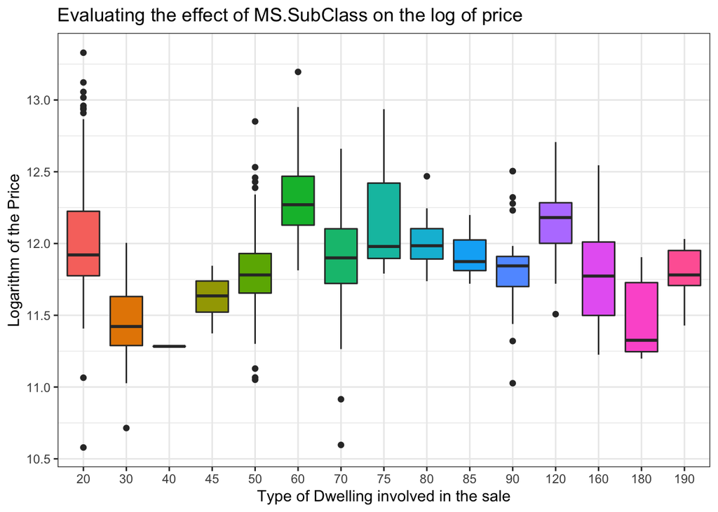

```r
ggplot(ames_train, aes(x = MS.SubClass, y = log.price, fill = MS.SubClass)) +
  geom_boxplot() + theme_bw() +
  scale_fill_discrete(guide=FALSE) +
  labs(
    title='Evaluating the effect of MS.SubClass on the log of price',
    x='Type of Dwelling involved in the sale',
    y='Logarithm of the Price')
```

According to this graphic, there exists some variability in the prices of the houses according to the types of Dwelling involved in the sale (only exception seems to be the 40 - 1-STORY W/FINISHED ATTIC ALL AGES dwelling). The types with highest price median are the 60 (2-STORY 1946 & NEWER) and the 120 (1-STORY PUD (Planned Unit Development) - 1946 & NEWER) subtypes.

### 2.1.3 Graphic 2: Effect of when the house was built (Year.Built) and House Style (House.Style) on log of price

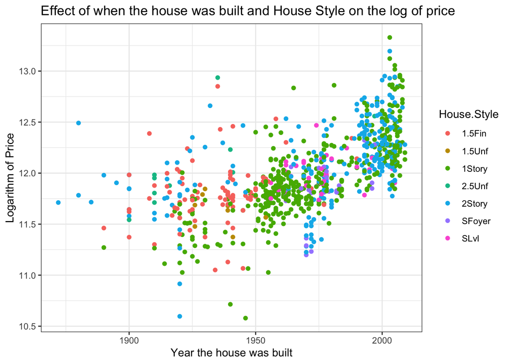

```r
ggplot(ames_train, aes(x = Year.Built, y = log.price, col=House.Style)) + geom_point() + theme_bw() + labs(title='Effect of when the house was built and House Style on the log of price', x = 'Year the house was built', y = 'Logarithm of Price')
```

### 2.1.4 Graphic 3: Effect of Heating Quality and condition on the Log Price

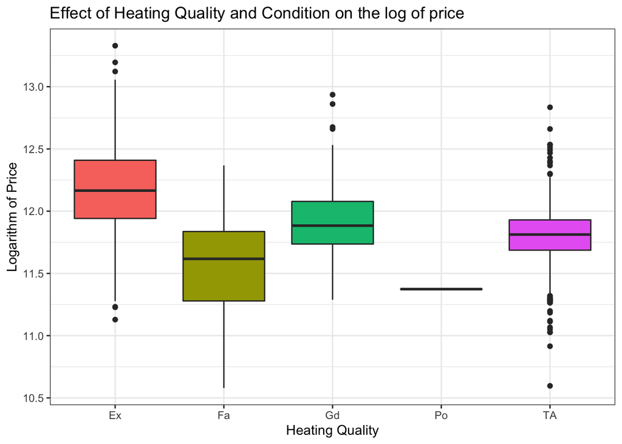

```r
ggplot(ames_train, aes(x = Heating.QC, y = log.price, fill=Heating.QC)) + geom_boxplot() + theme_bw() + labs(title='Effect of Heating Quality and Condition on the log of price', x = 'Heating Quality', y = 'Logarithm of Price') + scale_fill_discrete(guide=FALSE)
```

Expected houses with excellent heating quality tend to be higher priced than the other houses, followed by houses with a good quality. Houses with fair quality show lower prices. * * *

## 2.2 Part 2 - Development and assessment of an initial model, following a semi-guided process of analysis

### 2.2.1 Section 2.1 An Initial Model

In building a model, it is often useful to start by creating a simple, intuitive initial model based on the results of the exploratory data analysis. (Note: The goal at this stage is **not** to identify the “best” possible model but rather to choose a reasonable and understandable starting point. Later you will expand and revise this model to create your final model.

Based on your EDA, select *at most* 10 predictor variables from “ames_train” and create a linear model for `price` (or a transformed version of price) using those variables. Provide the *R code* and the *summary output table* for your model, a *brief justification* for the variables you have chosen, and a *brief discussion* of the model results in context (focused on the variables that appear to be important predictors and how they relate to sales price).

```r
initial_model <- lm(log(price) ~ log(Lot.Area) + MS.SubClass +
                      Overall.Qual +
                      Overall.Cond + Heating.QC +
                      Year.Built + House.Style +
                      Neighborhood + Exterior.1st +
                      X1st.Flr.SF, data = ames_train)

summary(initial_model)
```

```
##
## Call:
## lm(formula = log(price) ~ log(Lot.Area) + MS.SubClass + Overall.Qual +
##     Overall.Cond + Heating.QC + Year.Built + House.Style + Neighborhood +
##     Exterior.1st + X1st.Flr.SF, data = ames_train)
##
## Residuals:
##      Min       1Q   Median       3Q      Max
## -0.81978 -0.06178  0.00189  0.06245  0.46222
##
## Coefficients:
##                       Estimate Std. Error t value Pr(>|t|)
## (Intercept)          9.343e-01  9.516e-01   0.982 0.326518
## log(Lot.Area)        1.200e-01  1.404e-02   8.550  < 2e-16 ***
## MS.SubClass30       -3.314e-02  2.828e-02  -1.172 0.241576
## MS.SubClass40       -2.447e-01  1.189e-01  -2.058 0.039956 *
## MS.SubClass45       -5.956e-03  1.317e-01  -0.045 0.963951
## MS.SubClass50       -2.844e-02  5.803e-02  -0.490 0.624273
## MS.SubClass60       -7.022e-02  5.027e-02  -1.397 0.162917
## MS.SubClass70       -6.679e-02  5.531e-02  -1.208 0.227543
## MS.SubClass75        9.773e-03  7.274e-02   0.134 0.893159
## MS.SubClass80       -1.155e-01  9.489e-02  -1.218 0.223733
## MS.SubClass85       -5.471e-02  5.595e-02  -0.978 0.328454
## MS.SubClass90       -1.457e-01  3.162e-02  -4.609 4.76e-06 ***
## MS.SubClass120      -9.528e-03  2.504e-02  -0.380 0.703712
## MS.SubClass160      -1.450e-01  5.944e-02  -2.440 0.014936 *
## MS.SubClass180      -1.466e-01  7.505e-02  -1.954 0.051110 .
## MS.SubClass190      -1.647e-02  4.340e-02  -0.379 0.704436
## Overall.Qual2        1.170e-01  1.423e-01   0.822 0.411309
## Overall.Qual3        3.034e-01  1.328e-01   2.285 0.022584 *
## Overall.Qual4        3.537e-01  1.286e-01   2.751 0.006092 **
## Overall.Qual5        3.998e-01  1.281e-01   3.121 0.001870 **
## Overall.Qual6        4.667e-01  1.286e-01   3.629 0.000303 ***
## Overall.Qual7        5.491e-01  1.293e-01   4.247 2.44e-05 ***
## Overall.Qual8        6.119e-01  1.305e-01   4.688 3.27e-06 ***
## Overall.Qual9        7.672e-01  1.333e-01   5.753 1.27e-08 ***
## Overall.Qual10       8.339e-01  1.441e-01   5.787 1.05e-08 ***
## Overall.Cond2        2.776e-01  1.544e-01   1.798 0.072646 .
## Overall.Cond3        1.183e-01  1.053e-01   1.123 0.261596
## Overall.Cond4        2.838e-01  9.957e-02   2.850 0.004491 **
```

[output cut: 45 more lines]

```
## Exterior.1stHdBoard  3.596e-02  4.622e-02   0.778 0.436847
## Exterior.1stImStucc  3.155e-02  1.249e-01   0.253 0.800613
## Exterior.1stMetalSd  6.570e-02  4.526e-02   1.452 0.147028
## Exterior.1stPlywood  2.172e-02  4.753e-02   0.457 0.647850
## Exterior.1stStucco   1.335e-01  5.399e-02   2.473 0.013626 *
## Exterior.1stVinylSd  5.207e-02  4.608e-02   1.130 0.258840
## Exterior.1stWd Sdng  7.285e-02  4.524e-02   1.610 0.107765
## Exterior.1stWdShing  2.790e-02  5.212e-02   0.535 0.592623
## X1st.Flr.SF          4.142e-04  1.938e-05  21.374  < 2e-16 ***
## ---
## Signif. codes:  0 '***' 0.001 '**' 0.01 '*' 0.05 '.' 0.1 ' ' 1
##
## Residual standard error: 0.1134 on 752 degrees of freedom
## Multiple R-squared:  0.9204, Adjusted R-squared:  0.9118
## F-statistic: 107.3 on 81 and 752 DF,  p-value: < 2.2e-16
```

I chose those ten variables with a combination of past assessments, the plotted graphics in this assessment and a bit of general intuition and expert knowledge. From past assessments, the Lot Area was highly correlated with price (albeit needing both to be transformed into their log scale), as well as Overall.Qual and Overall.Cond, Neighbourhood and Year.Built, which makes sense as since the prime mantra of selling houses is location, both the condition and quality of the house, as well as their neighbourhood and age will probably be correlated with selling price. Also, with the plots created in this assessement, Heating Quality and the Subclass of the Dwelling as well as the House Style seemed to be correlated with selling prices. Finally, it made intuitive sense that the exterior covering on house (Exterior.1st) and the square feet area of the first floor (didn’t choose 2nd floor as well as some of the houses don’t have 2nd floors) would also have an effect on selling prices.

The adjusted R^2 for this model is 91.2%, which means that these variables explain 91.2% of the variance in the logarithm of the selling prices of the houses in this training set which is very good.

### 2.2.2 Section 2.2 Model Selection

Now either using `BAS` another stepwise selection procedure choose the “best” model you can, using your initial model as your starting point. Try at least two different model selection methods and compare their results. Do they both arrive at the same model or do they disagree? What do you think this means?

From the initial model as the starting point, I will use a backwards stepwise approach using both AIC and BIC as criteria to choose the better model.

### 2.2.3 AIC

```r
initial_model_AIC <- stepAIC(initial_model,
                             direction = 'backward', trace = FALSE)

summary(initial_model_AIC)
```

```
##
## Call:
## lm(formula = log(price) ~ log(Lot.Area) + MS.SubClass + Overall.Qual +
##     Overall.Cond + Heating.QC + Year.Built + House.Style + Neighborhood +
##     Exterior.1st + X1st.Flr.SF, data = ames_train)
##
## Residuals:
##      Min       1Q   Median       3Q      Max
## -0.81978 -0.06178  0.00189  0.06245  0.46222
##
## Coefficients:
##                       Estimate Std. Error t value Pr(>|t|)
## (Intercept)          9.343e-01  9.516e-01   0.982 0.326518
## log(Lot.Area)        1.200e-01  1.404e-02   8.550  < 2e-16 ***
## MS.SubClass30       -3.314e-02  2.828e-02  -1.172 0.241576
## MS.SubClass40       -2.447e-01  1.189e-01  -2.058 0.039956 *
## MS.SubClass45       -5.956e-03  1.317e-01  -0.045 0.963951
## MS.SubClass50       -2.844e-02  5.803e-02  -0.490 0.624273
## MS.SubClass60       -7.022e-02  5.027e-02  -1.397 0.162917
## MS.SubClass70       -6.679e-02  5.531e-02  -1.208 0.227543
## MS.SubClass75        9.773e-03  7.274e-02   0.134 0.893159
## MS.SubClass80       -1.155e-01  9.489e-02  -1.218 0.223733
## MS.SubClass85       -5.471e-02  5.595e-02  -0.978 0.328454
## MS.SubClass90       -1.457e-01  3.162e-02  -4.609 4.76e-06 ***
## MS.SubClass120      -9.528e-03  2.504e-02  -0.380 0.703712
## MS.SubClass160      -1.450e-01  5.944e-02  -2.440 0.014936 *
## MS.SubClass180      -1.466e-01  7.505e-02  -1.954 0.051110 .
## MS.SubClass190      -1.647e-02  4.340e-02  -0.379 0.704436
## Overall.Qual2        1.170e-01  1.423e-01   0.822 0.411309
## Overall.Qual3        3.034e-01  1.328e-01   2.285 0.022584 *
## Overall.Qual4        3.537e-01  1.286e-01   2.751 0.006092 **
## Overall.Qual5        3.998e-01  1.281e-01   3.121 0.001870 **
## Overall.Qual6        4.667e-01  1.286e-01   3.629 0.000303 ***
## Overall.Qual7        5.491e-01  1.293e-01   4.247 2.44e-05 ***
## Overall.Qual8        6.119e-01  1.305e-01   4.688 3.27e-06 ***
## Overall.Qual9        7.672e-01  1.333e-01   5.753 1.27e-08 ***
## Overall.Qual10       8.339e-01  1.441e-01   5.787 1.05e-08 ***
## Overall.Cond2        2.776e-01  1.544e-01   1.798 0.072646 .
## Overall.Cond3        1.183e-01  1.053e-01   1.123 0.261596
## Overall.Cond4        2.838e-01  9.957e-02   2.850 0.004491 **
```

[output cut: 45 more lines]

```
## Exterior.1stHdBoard  3.596e-02  4.622e-02   0.778 0.436847
## Exterior.1stImStucc  3.155e-02  1.249e-01   0.253 0.800613
## Exterior.1stMetalSd  6.570e-02  4.526e-02   1.452 0.147028
## Exterior.1stPlywood  2.172e-02  4.753e-02   0.457 0.647850
## Exterior.1stStucco   1.335e-01  5.399e-02   2.473 0.013626 *
## Exterior.1stVinylSd  5.207e-02  4.608e-02   1.130 0.258840
## Exterior.1stWd Sdng  7.285e-02  4.524e-02   1.610 0.107765
## Exterior.1stWdShing  2.790e-02  5.212e-02   0.535 0.592623
## X1st.Flr.SF          4.142e-04  1.938e-05  21.374  < 2e-16 ***
## ---
## Signif. codes:  0 '***' 0.001 '**' 0.01 '*' 0.05 '.' 0.1 ' ' 1
##
## Residual standard error: 0.1134 on 752 degrees of freedom
## Multiple R-squared:  0.9204, Adjusted R-squared:  0.9118
## F-statistic: 107.3 on 81 and 752 DF,  p-value: < 2.2e-16
```

### 2.2.4 BIC

```r
initial_model_BIC <- stepAIC(initial_model,
                             direction='backward',
                             k = log(nrow(ames_train)), trace = FALSE)

summary(initial_model_BIC)
```

```
##
## Call:
## lm(formula = log(price) ~ log(Lot.Area) + Overall.Qual + Overall.Cond +
##     Heating.QC + Year.Built + House.Style + X1st.Flr.SF, data = ames_train)
##
## Residuals:
##      Min       1Q   Median       3Q      Max
## -0.78931 -0.07107  0.00531  0.07199  0.46587
##
## Coefficients:
##                     Estimate Std. Error t value Pr(>|t|)
## (Intercept)        1.749e+00  5.313e-01   3.292 0.001038 **
## log(Lot.Area)      1.418e-01  9.636e-03  14.718  < 2e-16 ***
## Overall.Qual2      3.798e-02  1.512e-01   0.251 0.801649
## Overall.Qual3      2.129e-01  1.413e-01   1.507 0.132157
## Overall.Qual4      2.710e-01  1.375e-01   1.971 0.049058 *
## Overall.Qual5      3.607e-01  1.370e-01   2.633 0.008622 **
## Overall.Qual6      4.449e-01  1.377e-01   3.231 0.001285 **
## Overall.Qual7      5.461e-01  1.383e-01   3.950 8.51e-05 ***
## Overall.Qual8      6.842e-01  1.392e-01   4.915 1.07e-06 ***
## Overall.Qual9      8.413e-01  1.420e-01   5.924 4.67e-09 ***
## Overall.Qual10     9.166e-01  1.537e-01   5.962 3.72e-09 ***
## Overall.Cond2      4.316e-01  1.620e-01   2.665 0.007854 **
## Overall.Cond3      2.035e-01  1.072e-01   1.899 0.057975 .
## Overall.Cond4      3.599e-01  1.004e-01   3.586 0.000356 ***
## Overall.Cond5      4.583e-01  1.001e-01   4.579 5.40e-06 ***
## Overall.Cond6      4.965e-01  9.988e-02   4.971 8.15e-07 ***
## Overall.Cond7      5.608e-01  1.001e-01   5.600 2.95e-08 ***
## Overall.Cond8      5.803e-01  1.009e-01   5.749 1.27e-08 ***
## Overall.Cond9      5.863e-01  1.076e-01   5.449 6.72e-08 ***
## Heating.QCFa      -1.242e-01  3.346e-02  -3.713 0.000219 ***
## Heating.QCGd      -7.129e-03  1.324e-02  -0.538 0.590440
## Heating.QCPo      -1.292e-01  1.351e-01  -0.956 0.339301
## Heating.QCTA      -6.051e-02  1.181e-02  -5.121 3.80e-07 ***
## Year.Built         3.880e-03  2.535e-04  15.308  < 2e-16 ***
## House.Style1.5Unf -1.699e-01  4.995e-02  -3.402 0.000702 ***
## House.Style1Story -1.443e-01  1.752e-02  -8.236 7.18e-16 ***
## House.Style2.5Unf  9.087e-02  4.434e-02   2.049 0.040742 *
## House.Style2Story  6.890e-02  1.818e-02   3.790 0.000162 ***
## House.StyleSFoyer -7.202e-02  2.841e-02  -2.535 0.011428 *
## House.StyleSLvl   -1.106e-01  2.619e-02  -4.224 2.68e-05 ***
## X1st.Flr.SF        4.072e-04  1.883e-05  21.630  < 2e-16 ***
## ---
## Signif. codes:  0 '***' 0.001 '**' 0.01 '*' 0.05 '.' 0.1 ' ' 1
##
## Residual standard error: 0.1257 on 803 degrees of freedom
## Multiple R-squared:  0.8955, Adjusted R-squared:  0.8916
## F-statistic: 229.4 on 30 and 803 DF,  p-value: < 2.2e-16
```

According to the results, both approaches do not arrive at the same model. The model using BIC as criteria arrives to a model with a lower adjusted R^2 but with lesser predictor variables resulting in a more parsimonious model which is excellent for interpretation and fits with BIC objective which is to allow consistent estimation of the underlying data generating process.

The model using AIC as criteria arrives to a model with higher adjusted R^2 and using more predictor variables, which is the initial model without any changes. This fits with AIC objective which is better for prediction as it is asymptotically equivalent to cross-validation, at the cost of a more parsimonious explanation.

The differences between the criteria explain why they disagree. As the main objective of this assessment is predicting the selling prices of houses, I will stick with the AIC model as it fulfill that objective better. * * *

### 2.2.5 Section 2.3 Initial Model Residuals

One way to assess the performance of a model is to examine the model’s residuals. In the space below, create a residual plot for your preferred model from above and use it to assess whether your model appears to fit the data well. Comment on any interesting structure in the residual plot (trend, outliers, etc.) and briefly discuss potential implications it may have for your model and inference / prediction you might produce.

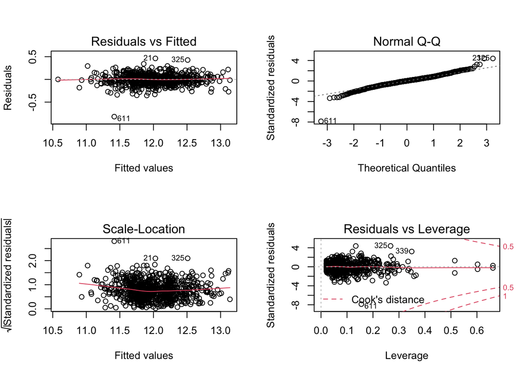

```r
par(mfrow=c(2,2))
plot(initial_model_AIC)
```

By examining the residual plots, there appears to be no major problem with the residuals of the model apart from some high leverage outliers (rows 325, 339 and 611). This is expected when using categorical variables for building a regression model as it’s hard for a subject to be a serious outlier in terms of a predictor if that predictor only has a few possible levels. I am expecting no serious implications in my model inference or predictions with such residual plots. The heavier tails of the distribution could be a problem, however the sample is so big that it won’t be a problem due to the Central Limit Theorem. Even so, it would only impact our estimation/inference capacity. As the main goal here is prediction, this does not seem to be a problem. * * *

### 2.2.6 Section 2.4 Initial Model RMSE

You can calculate it directly based on the model output. Be specific about the units of your RMSE (depending on whether you transformed your response variable). The value you report will be more meaningful if it is in the original units (dollars).

```r
# Extract Predictions
predictions_initial <- exp(predict(initial_model_AIC, ames_train))

# Extract Residuals
residuals_initial <- ames_train$price - predictions_initial

# Calculate RMSE
rmse_initial <- sqrt(mean(residuals_initial^2))

rmse_initial
```

```
## [1] 20376.42
```

The RMSE (root mean square error) for this initial model is 20376.42 dollars. * * *

### 2.2.7 Section 2.5 Overfitting

The process of building a model generally involves starting with an initial model (as you have done above), identifying its shortcomings, and adapting the model accordingly. This process may be repeated several times until the model fits the data reasonably well. However, the model may do well on training data but perform poorly out-of-sample (meaning, on a dataset other than the original training data) because the model is overly-tuned to specifically fit the training data. This is called “overfitting.” To determine whether overfitting is occurring on a model, compare the performance of a model on both in-sample and out-of-sample data sets. To look at performance of your initial model on out-of-sample data, you will use the data set `ames_test`.

```r
load("ames_test.Rdata")
```

Use your model from above to generate predictions for the housing prices in the test data set. Are the predictions significantly more accurate (compared to the actual sales prices) for the training data than the test data? Why or why not? Briefly explain how you determined that (what steps or processes did you use)?

```r
ames_test <- ames_test %>%
  mutate(Alley = if_else(is.na(Alley), 'No Alley Access', as.character(Alley)),
         Bsmt.Qual = if_else(is.na(Bsmt.Qual), 'No Basement', as.character(Bsmt.Qual)),
         Bsmt.Cond = if_else(is.na(Bsmt.Cond), 'No Basement', as.character(Bsmt.Cond)),
         Bsmt.Exposure = if_else(is.na(Bsmt.Exposure), 'No Basement', as.character(Bsmt.Cond)),
         BsmtFin.Type.1 = if_else(is.na(BsmtFin.Type.1), 'No Basement', as.character(BsmtFin.Type.1)),
         BsmtFin.Type.2 = if_else(is.na(BsmtFin.Type.2), 'No Basement', as.character(BsmtFin.Type.2)),
         Fireplace.Qu = if_else(is.na(Fireplace.Qu), 'No Fireplace', as.character(Fireplace.Qu)),
         Garage.Type = if_else(is.na(Garage.Type), 'No Garage', as.character(Garage.Type)),
         Garage.Finish = if_else(is.na(Garage.Finish), 'No Garage', as.character(Garage.Finish)),
         Garage.Qual = if_else(is.na(Garage.Qual), 'No Garage', as.character(Garage.Qual)),
         Garage.Cond = if_else(is.na(Garage.Cond), 'No Garage', as.character(Garage.Cond)),
         Pool.QC = if_else(is.na(Pool.QC), 'No Pool', as.character(Pool.QC)),
         Fence = if_else(is.na(Fence), 'No Fence', as.character(Fence)),
         Misc.Feature = if_else(is.na(Misc.Feature), 'No Misc Features', as.character(Misc.Feature)),
         Years.Old = 2018 - Year.Built,
         MS.SubClass = as.factor(MS.SubClass),
         Overall.Qual = as.factor(Overall.Qual),
         Overall.Cond = as.factor(Overall.Cond),
         log.price = log(price),
         log.Lot.Area = log(Lot.Area))
```

There is one problem to solve yet, as I used the House.Style variable to build the model. The test data has 2 houses with the House.Style 2.5Fin where none existed in the training data. Calculating the predictions in the new test data will thus result in an error. The only solution I found was to remove the 2 houses with this problem from the test dataset. The same problem happens with the predictor Neighborhood as the test data has rows with the level Landmark and the predictor Exterior.1st. The same solution was used to eliminate the rows with this problem.

```r
ames_test <- ames_test %>%
  filter(House.Style != '2.5Fin') %>%
  filter(Neighborhood != 'Landmrk') %>%
  filter(Exterior.1st != 'AsphShn')


predictions_test <- exp(predict(initial_model_AIC,ames_test))
residuals_test <- ames_test$price - predictions_test

rmse_test <- sqrt(mean(residuals_test^2))
rmse_test
```

```
## [1] 23613.98
```

As the RMSE rises with the predictions in the test data, we can conclude,as expected, that this model fits the training data better than out of sample data. A way of simplifying the model as suggested would be perhaps to use the model built with the BIC instead of the AIC.

Note to the learner: If in real-life practice this out-of-sample analysis shows evidence that the training data fits your model a lot better than the test data, it is probably a good idea to go back and revise the model (usually by simplifying the model) to reduce this overfitting. For simplicity, we do not ask you to do this on the assignment, however. * * *

**Note to the learner:** If in real-life practice this out-of-sample analysis shows evidence that the training data fits your model a lot better than the test data, it is probably a good idea to go back and revise the model (usually by simplifying the model) to reduce this overfitting. For simplicity, we do not ask you to do this on the assignment, however.

## 2.3 Part 3 Development of a Final Model

Now that you have developed an initial model to use as a baseline, create a final model with *at most* 20 variables to predict housing prices in Ames, IA, selecting from the full array of variables in the dataset and using any of the tools that we introduced in this specialization.

Carefully document the process that you used to come up with your final model, so that you can answer the questions below.

### 2.3.1 Section 3.1 Final Model

Provide the summary table for your model.

As the initial model already showed a good predictive power with a low RMSE in the test data, I’m not going to do many alterations on it other than try to improve its accuracy with a few more variables to differentiate lower quality houses from higher quality houses. Thus, I will try to add the Year.Remod.Add, Garage.Area, Bsmt.Qual and Pool.QC variables to the initial model.

```r
final_model <- lm(log(price) ~ log(Lot.Area) + MS.SubClass +
                    Overall.Qual + Overall.Cond + Heating.QC +
                    Year.Built + House.Style + Neighborhood +
                    Exterior.1st + X1st.Flr.SF + Year.Remod.Add +
                    Bsmt.Qual + Garage.Area + Pool.QC, data = ames_train)
```

Now to compare if the AIC criteria also chooses the same model using backward step selection:

```r
final_model_AIC <- step(final_model, direction='backward',
                        trace = FALSE)

final_model_AIC
```

```
##
## Call:
## lm(formula = log(price) ~ log(Lot.Area) + MS.SubClass + Overall.Qual +
##     Overall.Cond + Heating.QC + Year.Built + House.Style + Neighborhood +
##     Exterior.1st + X1st.Flr.SF + Year.Remod.Add + Bsmt.Qual +
##     Garage.Area + Pool.QC, data = ames_train)
##
## Coefficients:
##          (Intercept)         log(Lot.Area)         MS.SubClass30
##            0.7703524             0.1034355            -0.0494407
##        MS.SubClass40         MS.SubClass45         MS.SubClass50
##           -0.2519347            -0.0700470            -0.0330923
##        MS.SubClass60         MS.SubClass70         MS.SubClass75
##           -0.0344992            -0.0466195             0.0261264
##        MS.SubClass80         MS.SubClass85         MS.SubClass90
##           -0.0479479             0.0043472            -0.0889491
##       MS.SubClass120        MS.SubClass160        MS.SubClass180
##           -0.0144470            -0.1211142            -0.1144631
##       MS.SubClass190         Overall.Qual2         Overall.Qual3
##           -0.0248707             0.0658041             0.1388422
##        Overall.Qual4         Overall.Qual5         Overall.Qual6
##            0.2006287             0.2442514             0.3039198
##        Overall.Qual7         Overall.Qual8         Overall.Qual9
##            0.3833148             0.4355305             0.5501241
##       Overall.Qual10         Overall.Cond2         Overall.Cond3
##            0.5283166             0.4153341             0.1891467
##        Overall.Cond4         Overall.Cond5         Overall.Cond6
##            0.3173963             0.3919867             0.4333619
##        Overall.Cond7         Overall.Cond8         Overall.Cond9
##            0.4814563             0.4982292             0.5087935
##         Heating.QCFa          Heating.QCGd          Heating.QCPo
##           -0.0922195            -0.0027556            -0.0524307
##         Heating.QCTA            Year.Built     House.Style1.5Unf
##           -0.0271476             0.0035633            -0.1415186
##    House.Style1Story     House.Style2.5Unf     House.Style2Story
##           -0.1676994             0.0772414             0.0828086
##    House.StyleSFoyer       House.StyleSLvl   NeighborhoodBlueste
##           -0.0797133            -0.0897766            -0.0288367
##   NeighborhoodBrDale   NeighborhoodBrkSide   NeighborhoodClearCr
##           -0.1236434            -0.0373261             0.0317162
```

[output cut: 15 more lines]

```
##            0.0441231             0.2707707             0.1010640
##  Exterior.1stCemntBd   Exterior.1stHdBoard   Exterior.1stImStucc
##            0.1149466             0.0258691             0.0155796
##  Exterior.1stMetalSd   Exterior.1stPlywood    Exterior.1stStucco
##            0.0505972             0.0129309             0.1116177
##  Exterior.1stVinylSd   Exterior.1stWd Sdng   Exterior.1stWdShing
##            0.0277315             0.0574819             0.0162194
##          X1st.Flr.SF        Year.Remod.Add           Bsmt.QualFa
##            0.0003683             0.0012895            -0.0829082
##          Bsmt.QualGd  Bsmt.QualNo Basement           Bsmt.QualPo
##           -0.0635837            -0.2422905            -0.1951916
##          Bsmt.QualTA           Garage.Area             Pool.QCFa
##           -0.0693317             0.0001567            -0.2287028
##            Pool.QCGd        Pool.QCNo Pool
##           -0.3064662            -0.3213074
```

The AIC criteria also chooses the same model with the 14 selected predictor variables chosen. Now to compare this model with the initial one and check if it truly is better than the initial.

```r
anova(initial_model_AIC, final_model_AIC)
```

```
## Analysis of Variance Table
##
## Model 1: log(price) ~ log(Lot.Area) + MS.SubClass + Overall.Qual + Overall.Cond +
##     Heating.QC + Year.Built + House.Style + Neighborhood + Exterior.1st +
##     X1st.Flr.SF
## Model 2: log(price) ~ log(Lot.Area) + MS.SubClass + Overall.Qual + Overall.Cond +
##     Heating.QC + Year.Built + House.Style + Neighborhood + Exterior.1st +
##     X1st.Flr.SF + Year.Remod.Add + Bsmt.Qual + Garage.Area +
##     Pool.QC
##   Res.Df   RSS Df Sum of Sq      F    Pr(>F)
## 1    752 9.676
## 2    742 8.544 10     1.132 9.8305 1.483e-15 ***
## ---
## Signif. codes:  0 '***' 0.001 '**' 0.01 '*' 0.05 '.' 0.1 ' ' 1
```

The ANOVA results show that the new variables increase the predictive power of this new model compared to the older one. The final model summary thus is:

```r
summary(final_model_AIC)
```

```
##
## Call:
## lm(formula = log(price) ~ log(Lot.Area) + MS.SubClass + Overall.Qual +
##     Overall.Cond + Heating.QC + Year.Built + House.Style + Neighborhood +
##     Exterior.1st + X1st.Flr.SF + Year.Remod.Add + Bsmt.Qual +
##     Garage.Area + Pool.QC, data = ames_train)
##
## Residuals:
##      Min       1Q   Median       3Q      Max
## -0.84705 -0.05676 -0.00044  0.06029  0.42586
##
## Coefficients:
##                        Estimate Std. Error t value Pr(>|t|)
## (Intercept)           7.704e-01  1.054e+00   0.731 0.465216
## log(Lot.Area)         1.034e-01  1.371e-02   7.543 1.35e-13 ***
## MS.SubClass30        -4.944e-02  2.708e-02  -1.826 0.068277 .
## MS.SubClass40        -2.519e-01  1.125e-01  -2.239 0.025465 *
## MS.SubClass45        -7.005e-02  1.250e-01  -0.560 0.575537
## MS.SubClass50        -3.309e-02  5.546e-02  -0.597 0.550930
## MS.SubClass60        -3.450e-02  4.820e-02  -0.716 0.474347
## MS.SubClass70        -4.662e-02  5.283e-02  -0.882 0.377854
## MS.SubClass75         2.613e-02  6.905e-02   0.378 0.705267
## MS.SubClass80        -4.795e-02  9.017e-02  -0.532 0.595065
## MS.SubClass85         4.347e-03  5.353e-02   0.081 0.935299
## MS.SubClass90        -8.895e-02  3.105e-02  -2.865 0.004291 **
## MS.SubClass120       -1.445e-02  2.416e-02  -0.598 0.549993
## MS.SubClass160       -1.211e-01  5.705e-02  -2.123 0.034088 *
## MS.SubClass180       -1.145e-01  7.164e-02  -1.598 0.110543
## MS.SubClass190       -2.487e-02  4.125e-02  -0.603 0.546770
## Overall.Qual2         6.580e-02  1.349e-01   0.488 0.625941
## Overall.Qual3         1.388e-01  1.277e-01   1.087 0.277179
## Overall.Qual4         2.006e-01  1.238e-01   1.620 0.105583
## Overall.Qual5         2.443e-01  1.234e-01   1.979 0.048140 *
## Overall.Qual6         3.039e-01  1.240e-01   2.451 0.014463 *
## Overall.Qual7         3.833e-01  1.246e-01   3.076 0.002175 **
## Overall.Qual8         4.355e-01  1.258e-01   3.462 0.000568 ***
## Overall.Qual9         5.501e-01  1.296e-01   4.246 2.46e-05 ***
## Overall.Qual10        5.283e-01  1.426e-01   3.706 0.000226 ***
## Overall.Cond2         4.153e-01  1.483e-01   2.801 0.005223 **
## Overall.Cond3         1.891e-01  1.018e-01   1.858 0.063619 .
```

[output cut: 56 more lines]

```
## Bsmt.QualFa          -8.291e-02  3.817e-02  -2.172 0.030173 *
## Bsmt.QualGd          -6.358e-02  2.253e-02  -2.823 0.004890 **
## Bsmt.QualNo Basement -2.423e-01  3.841e-02  -6.308 4.86e-10 ***
## Bsmt.QualPo          -1.952e-01  1.175e-01  -1.662 0.096974 .
## Bsmt.QualTA          -6.933e-02  2.659e-02  -2.607 0.009307 **
## Garage.Area           1.567e-04  2.648e-05   5.919 4.96e-09 ***
## Pool.QCFa            -2.287e-01  1.673e-01  -1.367 0.171966
## Pool.QCGd            -3.065e-01  1.745e-01  -1.756 0.079483 .
## Pool.QCNo Pool       -3.213e-01  1.257e-01  -2.557 0.010751 *
## ---
## Signif. codes:  0 '***' 0.001 '**' 0.01 '*' 0.05 '.' 0.1 ' ' 1
##
## Residual standard error: 0.1073 on 742 degrees of freedom
## Multiple R-squared:  0.9297, Adjusted R-squared:  0.921
## F-statistic: 107.8 on 91 and 742 DF,  p-value: < 2.2e-16
```

### 2.3.2 Section 3.2 Transformation

Did you decide to transform any variables? Why or why not? Explain in a few sentences.

Yes, as learned in the previous quizzes, Lot.Area needs to be log transformed as well as price due to their skeweness. The same doesn’t happen with any other other variables used in the model so there is no need for transformations.

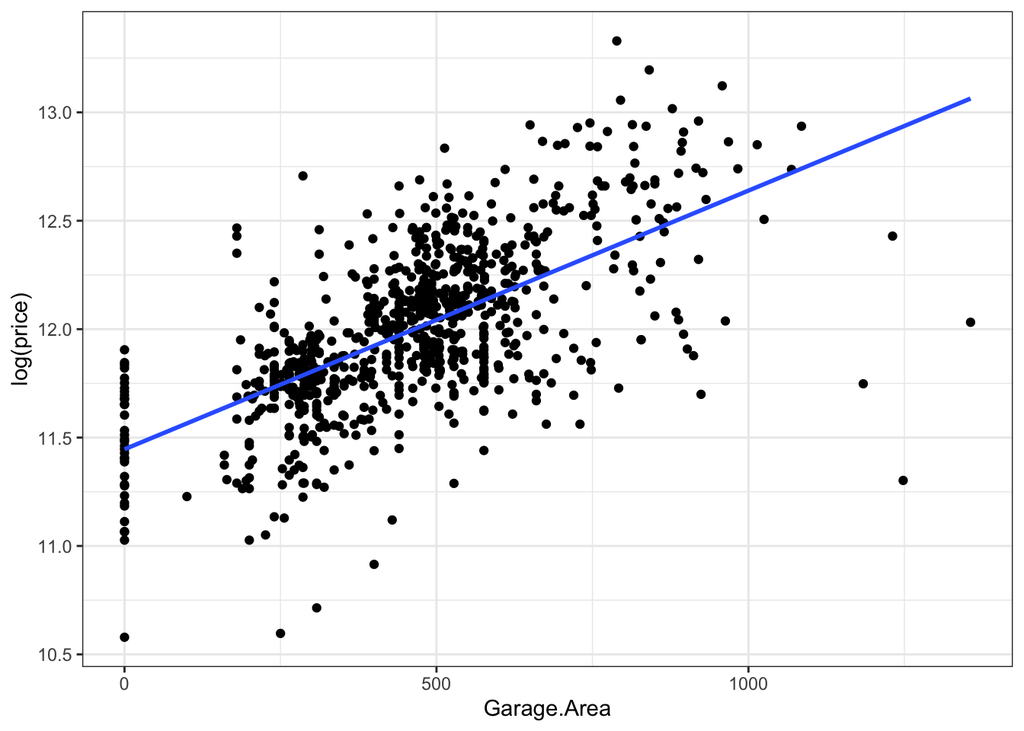

```r
ggplot(ames_train, aes(x = Garage.Area, y = log(price))) +
  geom_point() +
  theme_bw() +
  geom_smooth(method='lm', se = FALSE)
```

### 2.3.3 Section 3.3 Variable Interaction

Did you decide to include any variable interactions? Why or why not? Explain in a few sentences.

As the concept of variable interactions was not approached in any of the courses of the specialization, I decided not to include any variable interactions. Also, at first glance, not many variables exists that seem to depend on each other as an interaction.

### 2.3.4 Section 3.4 Variable Selection

What method did you use to select the variables you included? Why did you select the method you used? Explain in a few sentences.

As explained before, the method I use to select the variables I included was based on the results of the previous quizzes, the exploratory data analysis done in this final project and some intuition and expert knowledge regarding the ultimate objective of house selling price prediction (for example, knowing that location is one of the most important mantras in house selling.). I checked my assumptions using a backward step approach using AIC as a criteria (due to it being better than BIC for prediction due to being equivalent to a cross-validation). The results obtained using this approach were the same as my original model.

### 2.3.5 Section 3.5 Model Testing

How did testing the model on out-of-sample data affect whether or how you changed your model? Explain in a few sentences.

I was very happy with the results from the initial model and its low RSME on the test data, even though it was a bit higher than the RMSE in the training data as expected. The final model resulted only from a try to add some more variables in order to improve predictive power. * * *

## 2.4 Part 4 Final Model Assessment

### 2.4.1 Section 4.1 Final Model Residual

For your final model, create and briefly interpret an informative plot of the residuals.

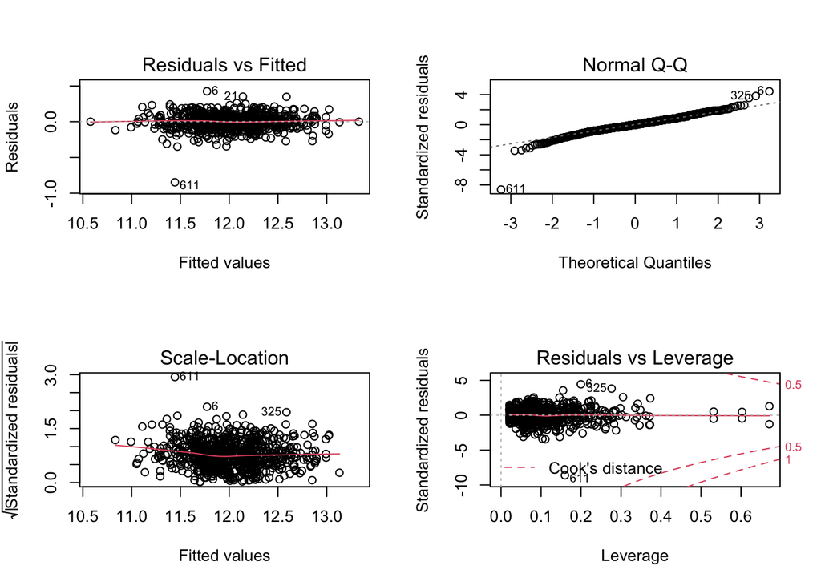

```r
par(mfrow=c(2,2))
plot(final_model_AIC)
```

Once again, other than the heavy tails on the normal distribution of the residuals, there does not appear to exist any major assumption violation in the residuals plots. This may bring some problems in the inference estimation of confidence intervals but as we are mainly interested in predictive power here and the sample number is large, this does not seem to be a major problem. Once again, some points show high leverage in the Cook’s plot but once again this is to be expected as the linear model uses so many categorical variables. * * *

### 2.4.2 Section 4.2 Final Model RMSE

For your final model, calculate and briefly comment on the RMSE.

```r
ames_test <- ames_test %>%
  filter(Pool.QC != 'TA')

predictions_final_test <- exp(predict(final_model_AIC,ames_test))
residuals_final_test <- ames_test$price - predictions_final_test

rmse_final_test <- sqrt(mean(residuals_final_test^2))
rmse_final_test
```

```
## [1] 24639.6
```

Sadly, it seems the final model shows a bigger RMSE compared to the initial model in the test data even though it has a better Adjusted R^2 than the initial model. Thus, it probably means this model is more overfitted than the initial one and better predictions may be made with the initial simpler model. * * *

### 2.4.3 Section 4.3 Final Model Evaluation

What are some strengths and weaknesses of your model?

Strengths:

- Good adjusted R<sup>2</sup>
- Does not appear to violate assumptions of linear regression
- Shows a good RMSE in the test data.

Weaknesses:

- Uses too many variables. Using BIC perhaps a more parsimonious model could be made.
- The model follows a frequentist approach and thus does not use any priors that could improve its predictive power based on previous knowledge.
- Has a higher RMSE than the initial simpler model.

### 2.4.4 Section 4.4 Final Model Validation

Testing your final model on a separate, validation data set is a great way to determine how your model will perform in real-life practice.

You will use the “ames_validation” dataset to do some additional assessment of your final model. Discuss your findings, be sure to mention: * What is the RMSE of your final model when applied to the validation data?  
* How does this value compare to that of the training data and/or testing data? * What percentage of the 95% predictive confidence (or credible) intervals contain the true price of the house in the validation data set?  
* From this result, does your final model properly reflect uncertainty?

```r
load("ames_validation.Rdata")
```

```r
ames_validation <- ames_validation %>%
  mutate(Alley = if_else(is.na(Alley), 'No Alley Access', as.character(Alley)),
         Bsmt.Qual = if_else(is.na(Bsmt.Qual), 'No Basement', as.character(Bsmt.Qual)),
         Bsmt.Cond = if_else(is.na(Bsmt.Cond), 'No Basement', as.character(Bsmt.Cond)),
         Bsmt.Exposure = if_else(is.na(Bsmt.Exposure), 'No Basement', as.character(Bsmt.Cond)),
         BsmtFin.Type.1 = if_else(is.na(BsmtFin.Type.1), 'No Basement', as.character(BsmtFin.Type.1)),
         BsmtFin.Type.2 = if_else(is.na(BsmtFin.Type.2), 'No Basement', as.character(BsmtFin.Type.2)),
         Fireplace.Qu = if_else(is.na(Fireplace.Qu), 'No Fireplace', as.character(Fireplace.Qu)),
         Garage.Type = if_else(is.na(Garage.Type), 'No Garage', as.character(Garage.Type)),
         Garage.Finish = if_else(is.na(Garage.Finish), 'No Garage', as.character(Garage.Finish)),
         Garage.Qual = if_else(is.na(Garage.Qual), 'No Garage', as.character(Garage.Qual)),
         Garage.Cond = if_else(is.na(Garage.Cond), 'No Garage', as.character(Garage.Cond)),
         Pool.QC = if_else(is.na(Pool.QC), 'No Pool', as.character(Pool.QC)),
         Fence = if_else(is.na(Fence), 'No Fence', as.character(Fence)),
         Misc.Feature = if_else(is.na(Misc.Feature), 'No Misc Features', as.character(Misc.Feature)),
         Years.Old = 2018 - Year.Built,
         MS.SubClass = as.factor(MS.SubClass),
         Overall.Qual = as.factor(Overall.Qual),
         Overall.Cond = as.factor(Overall.Cond),
         log.price = log(price),
         log.Lot.Area = log(Lot.Area))
```

```r
ames_validation <- ames_validation %>%
  filter(House.Style != '2.5Fin') %>%
  filter(Exterior.1st != 'CBlock' & Exterior.1st != 'PreCast') %>%
  filter(Pool.QC != 'TA') %>%
  filter(MS.SubClass != '150')

predictions_validation <- exp(predict(final_model_AIC,ames_validation))
residuals_validation <- ames_validation$price - predictions_validation

rmse_validation <- sqrt(mean(residuals_validation^2))
rmse_validation
```

```
## [1] 20494.79
```

Although the RMSE of the final model was higher in the test data compared to the initial model, in the validation data it achieves a lower RMSE (20494.79 dollars) than the one achieved in the test data (24639.6 dollars). This is a much better value than the one achieved in the test data and shows that perhaps the final model is not as overfitted to the training data as I originally thought.

Now to find the percentage of the 95% predictive confidence intervals that contain the true price of the house in the validation data set:

```r
# Predict prices
predict.full.CI <- exp(predict(final_model_AIC, ames_validation, interval = "prediction", level=0.95))

# Calculate proportion of observations that fall within prediction intervals
coverage.prob.full <- mean(ames_validation$price > predict.full.CI[,"lwr"] &
                            ames_validation$price < predict.full.CI[,"upr"])
coverage.prob.full
```

```
## [1] 0.9495352
```

The coverage probability of this final model is approximately 95%, thus this model properly reflects uncertainty. * * *

## 2.5 Part 5 Conclusion

Provide a brief summary of your results, and a brief discussion of what you have learned about the data and your model.

This dataset contains enough variables to build an interesting linear model that tries to predict the selling price for houses. Based on the reuslts from this model, it achieves a low RMSE in the validation data and quantifies uncertainty well. It also doesn’t have major problems in the diagnostic plots. The variables that seem to be more important for predicting the selling price of a house according to AIC and this model are the logarithm of the Lot Area, Overall.Qual, Overall.Cond, Heating.QC, Year.Built, House.Style, Neighborhood, Exterior.1st, X1st.Flr.SF, Year.Remod.Add, Bsmt.Qual, Garage.Area and Pool.QC. The final model has an adjusted R^2 of 92.1%, explaining 92.1% of the variance in the logarithm of house prices.

With this project I learned a lot about fitting linear models, exploring a new dataset, diagnosing problems and discovering how to choose and validate created models with test and validation data. Unfortunately, due to a lack of time I could only do this via a Frequentist Approach and I’m sure the Bayesian Approach results would also be interesting and would have the advantage of fitting priors that could quantify better some expert knowledge regarding the dataset.

In the future, collecting more variables in this dataset or using more advanced prediction methodologies than linear regression could contribute to achieve better predictive power starting with this final model as a scaffold.